# Assignment 13: Text Mining

*How to do it?*:

- Open the Rmarkdown file of this assignment (link) in Rstudio.
- Right under each **question**, insert a code chunk (you can use the hotkey `Ctrl + Alt + I` to add a code chunk) and code the solution for the question.
- `Knit` the rmarkdown file (hotkey: `Ctrl + Alt + K`) to export an html.
- Publish the html file to your Githiub Page.

*Submission*: Submit the link on Github of the assignment to Canvas

Sample Codes

### Netflix Data

**1.** Download the `netflix_titles` at this link. Create a century variable taking two values:

```
- '21' if the released_year is greater or equal to 2000, and

- '20' otherwise.
```

```r
#install.packages('wordcloud')
#install.packages('tidytext')
#install.packages('stopwords')
#install.packages('textrecipes')
#install.packages('yardstick')
library(wordcloud)
library(tidyverse)
library(tidytext)
library(knitr)
df <- read.csv('netflix_titles.csv')
```

```r
df$century <- case_when(df$release_year >= 2000 ~ '21',TRUE ~ '20')
```

**2. Word Frequency**

1. Convert the description to tokens, remove all the stop words. What are the top 10 frequent words of movies/TV Shows in the 20th century. Plot the bar chart of the frequency of these words.

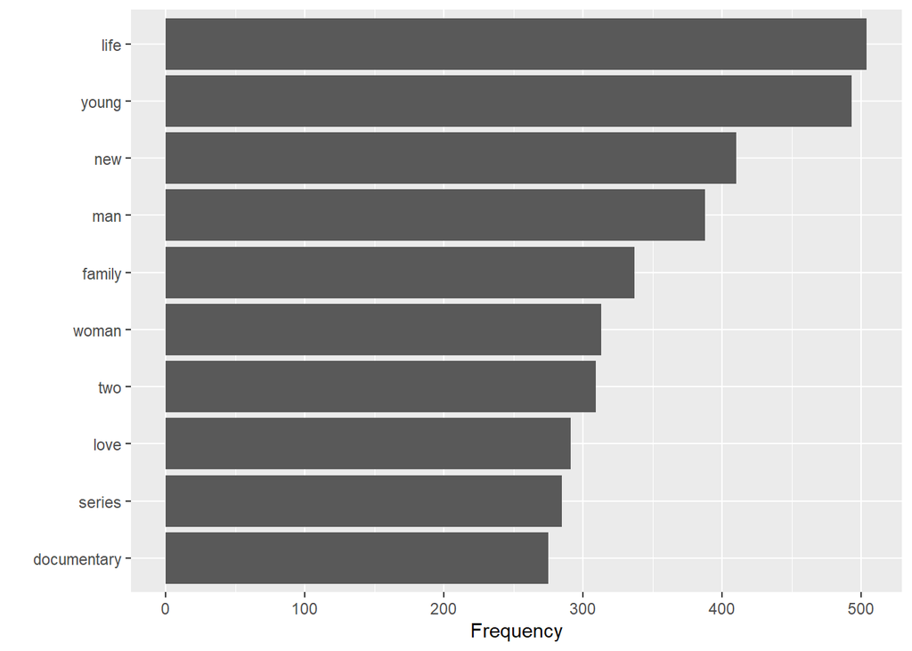

```r
df %>%
  unnest_tokens(input = description, output = word) %>%
  anti_join(get_stopwords()) %>%
  count(type, word, sort = TRUE) %>%
  head(10) %>%
  ggplot(aes(x = n, y = reorder(word, n))) +
  geom_col() +
  labs(x = 'Frequency', y= '')
```

2. What are the top 10 frequent words of movies/TV Shows in the 21st century. Plot the bar chart of the frequency of these words. Plot a side-by-side bar charts to compare the most frequent words by the two centuries.

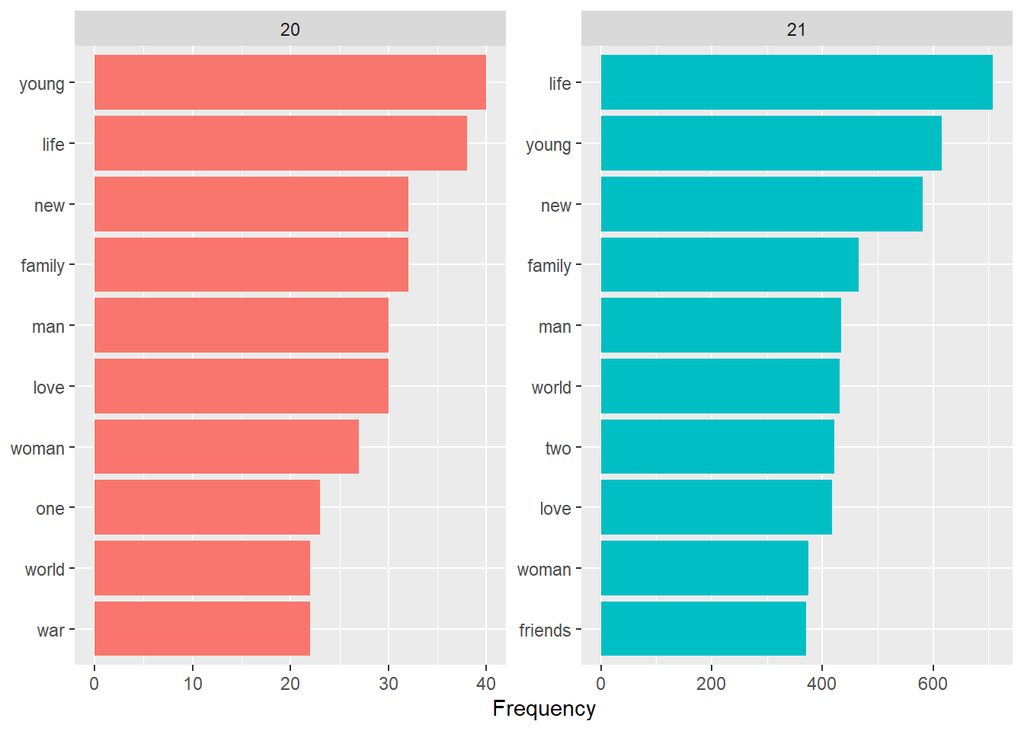

```r
df %>%
  unnest_tokens(input = description, output = word) %>%
  anti_join(get_stopwords()) %>%
  count(century, word, sort = TRUE) %>%
  group_by(century) %>%
  slice_max(n, n = 10) %>%
  ungroup() %>%
  mutate(word = reorder_within(word, by = n, within = century)) %>%
  ggplot(aes(n, word, fill = century)) +
  geom_col(show.legend = FALSE) +
  facet_wrap(~century, scales = "free") +
  labs(x = "Frequency", y = NULL)+
  scale_y_reordered()
```

**3. Word Cloud**

1. Plot the word cloud of the words in the descriptions in the movies/TV Shows in the 20th century.

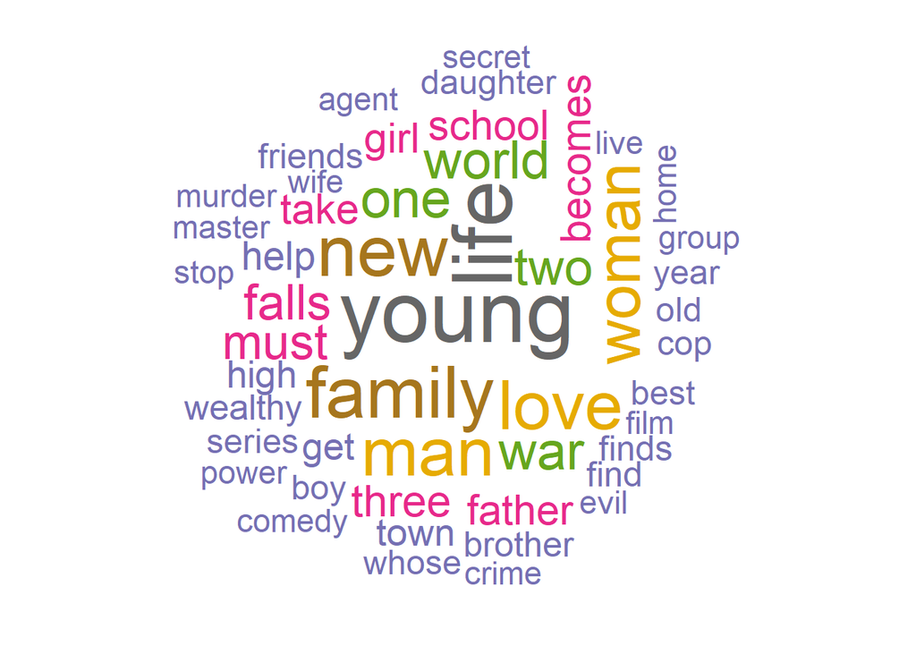

```r
install.packages('wordcloud')
pal <- brewer.pal(8,"Dark2")

df %>%
  filter(century=='20') %>%
  unnest_tokens(input = description, output = word) %>%
  anti_join(get_stopwords()) %>%
  count(word, sort = TRUE) %>%
  with(wordcloud(word, n, random.order = FALSE, max.words = 50, colors=pal))
```

2. Plot the word cloud of the words in the descriptions in the movies/TV Shows in the 21st century.

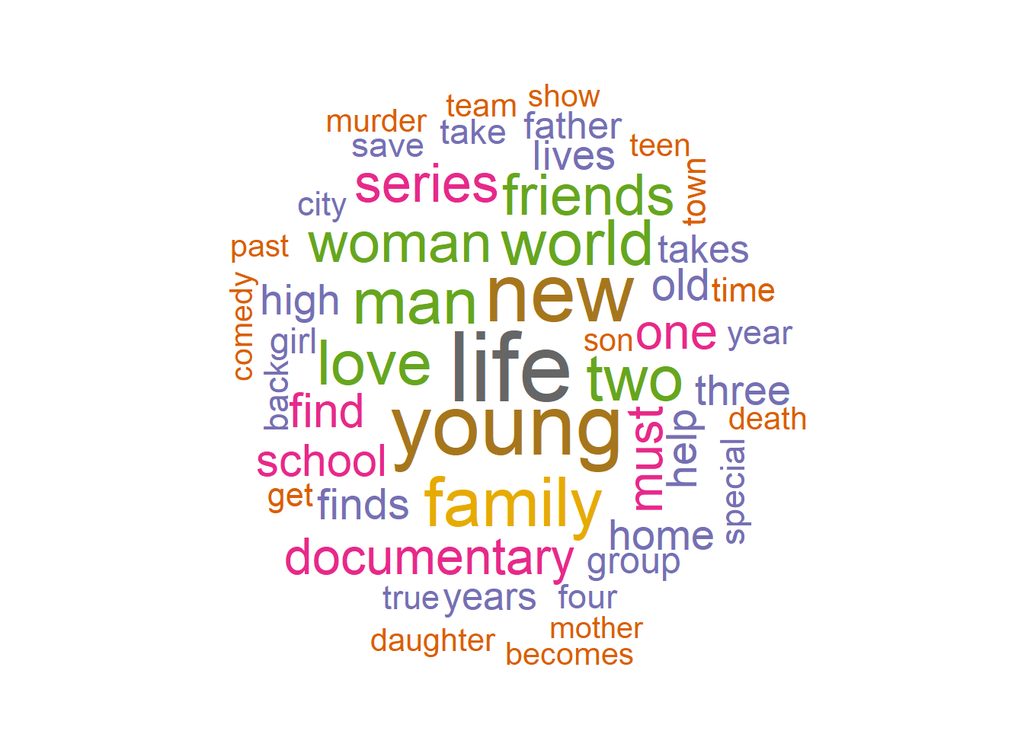

```r
df %>%
  filter(century=='21') %>%
  unnest_tokens(input = description, output = word) %>%
  anti_join(get_stopwords()) %>%
  count(word, sort = TRUE) %>%
  with(wordcloud(word, n, random.order = FALSE, max.words = 50, colors=pal))
```

**4. Sentiment Analysis**

1. Is movies/TV Shows in the 21st century tends to be more positive than those in 20th century? Use the sentiment analysis by `Bing` lexicons to address the question.

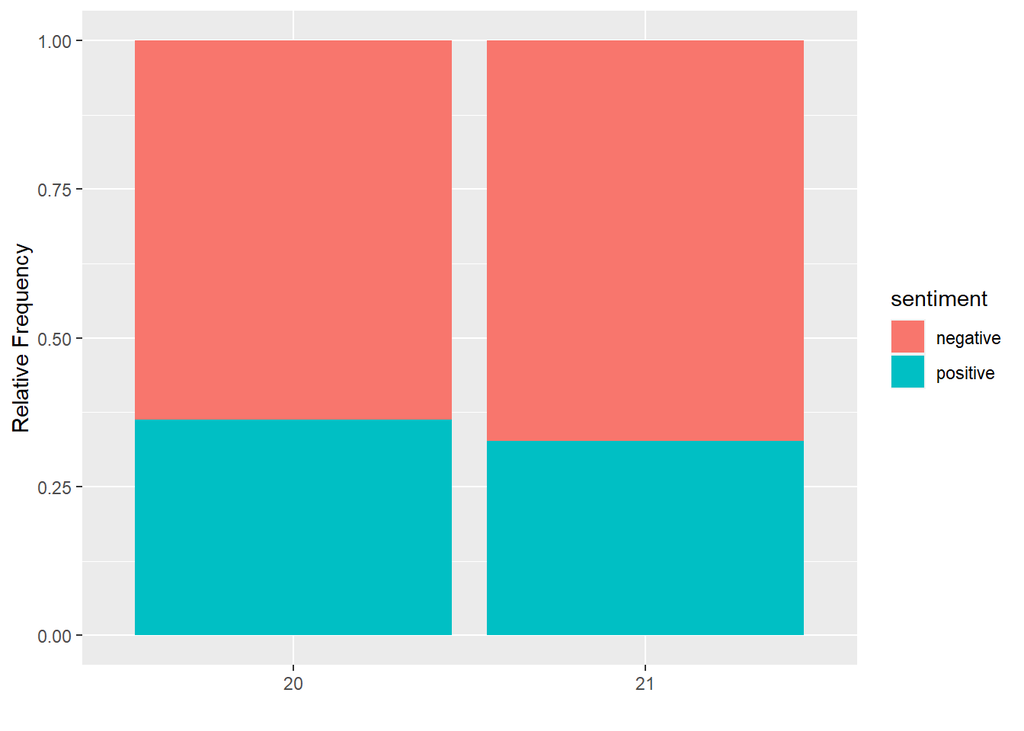

```r
df %>%
    mutate(century = if_else(release_year>=2000, '21','20')) %>%
    unnest_tokens(input = description, output = word) %>%
    anti_join(get_stopwords()) %>%
    count(century, word, sort = TRUE) %>%
    group_by(century) %>%
    inner_join(get_sentiments("bing")) %>%
    filter(!is.na(sentiment)) %>%
    count(sentiment, sort = TRUE) %>%
    group_by(century) %>%
    mutate(n = n/sum(n)) %>%
    ggplot(aes(century, n, fill=sentiment))+
    geom_col(position = 'fill')+
    labs(x ='', y='Relative Frequency')
```

2. Do sentiment analysis using `nrc` and `afinn` lexicons. Give your comments on the results.

```r
library(textdata)
```

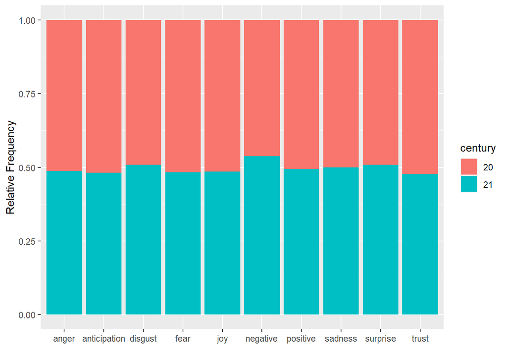

```r
df %>%
    unnest_tokens(input = description, output = word) %>%
    anti_join(get_stopwords()) %>%
    count(century, word, sort = TRUE) %>%
    group_by(century) %>%
    inner_join(get_sentiments("nrc")) %>%
    filter(!is.na(sentiment)) %>%
    count(sentiment, sort = TRUE) %>%
    group_by(century) %>%
    mutate(n = n/sum(n)) %>%
    ggplot(aes(sentiment, n, fill=century))+
    geom_col(position = 'fill')+
    labs(x='', y='Relative Frequency')
```

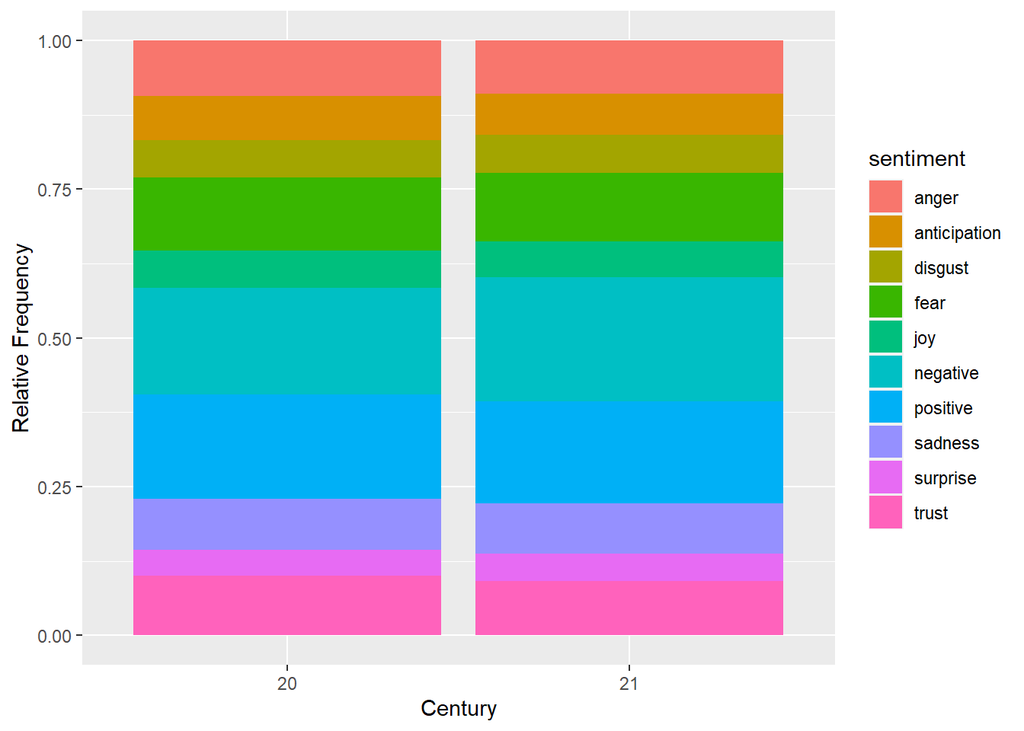

```r
df %>%
    unnest_tokens(input = description, output = word) %>%
    anti_join(get_stopwords()) %>%
    count(century, word, sort = TRUE) %>%
    group_by(century) %>%
    inner_join(get_sentiments("nrc")) %>%
    filter(!is.na(sentiment)) %>%
    count(sentiment, sort = TRUE) %>%
    group_by(century) %>%
    mutate(n = n/sum(n)) %>%
    ggplot(aes(century, n, fill=sentiment))+
    geom_col(position = 'fill')+
    labs(x='Century', y='Relative Frequency')
```

Big proportions for positive and negative sentiments, and a variety for evrything else.

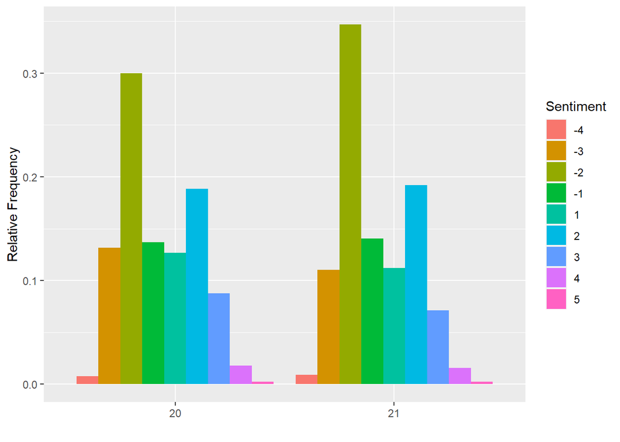

```r
df %>%
    unnest_tokens(input = description, output = word) %>%
    anti_join(get_stopwords()) %>%
    count(century, word, sort = TRUE) %>%
    group_by(century) %>%
    inner_join(get_sentiments("afinn")) %>%
    mutate(sentiment = value) %>%
    filter(!is.na(sentiment)) %>%
    count(sentiment, sort = TRUE) %>%
    group_by(century) %>%
    mutate(n = n/sum(n)) %>%
    ggplot(aes(century, n, fill=factor(sentiment)))+
    geom_col(position = 'dodge')+
    labs(x='', y='Relative Frequency', fill = 'Sentiment')
```

Both histograms look pretty much the same, with the sentiment value of -2 being the most common.

**5. Modeling**

1. Use the description to predict if a movie/TV show is in 20th or 21st century. Give the accuracy and plot the confusion matrix table.

```r
library(caret)
library(themis)
library(textrecipes)
library(yardstick)
df <- df %>%
  mutate(target = century) %>%
  select(target, description)

stuff <- recipe(target~description, data = df) %>%
  step_tokenize(description) %>%
  step_tokenfilter(description, max_tokens = 50) %>%
  step_tfidf(description) %>%
  step_normalize(all_numeric_predictors()) %>%
  step_smote(target) %>%
  prep()
df <- juice(stuff)

set.seed(2021)
splitIndex <- createDataPartition(df$target, p = .07, list = FALSE)
df_train <- df[splitIndex,]
df_test <- df[-splitIndex,]

ranger <- train(target ~., data=df_train, method = "ranger")
prediction1 <- predict(ranger, df_test)
confmatrix1 <- confusionMatrix(data = prediction1, reference = df_test$target)
confmatrix1$overall[1]
```

```
##  Accuracy
## 0.8676729
```

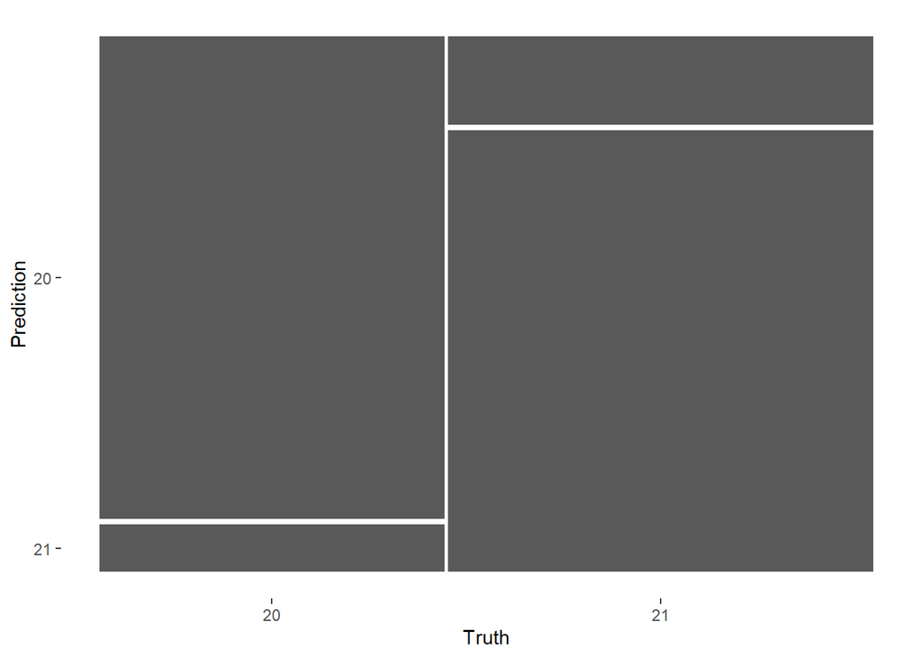

```r
df5_1 = data.frame(prediction1 = prediction1, obs = df_test$target)

df5_1 %>%
  conf_mat(prediction1, obs) %>%
  autoplot
```

2. Create variable century2 taking three following values. (Hint: You can use the case_when function to do this)

```r
df <- read.csv('netflix_titles.csv')
```

```
- `21` if released_year is greater or equal to 2000

- `second_half_20`if released_year is greater than or equal to 1950 and less than 2000

- `first_half_20` otherwise
```

```r
df$century2 <- case_when(df$release_year >= 2000 ~ "21", df$release_year >= 1950 ~ "second_half_20" , df$release_year>= 1900~"first_half_20")
```

Predict century2 using the descriptions. Give the accuracy and plot the confusion matrix table. (Notice that the codes for 8 should still work for this question)

```r
df <- df %>%
  mutate(target = century2) %>%
  select(target, description)

thing <- recipe(target~description, data = df) %>%
  step_tokenize(description) %>%
  step_tokenfilter(description, max_tokens = 50) %>%
  step_tfidf(description) %>%
  step_normalize(all_numeric_predictors()) %>%
  step_smote(target) %>%
  prep()
df <- juice(thing)

set.seed(2022)
splitIndex <- createDataPartition(df$target, p = .01, list = FALSE)
df_train <- df[splitIndex,]
df_test <- df[-splitIndex,]

ranger2 <- train(target ~., data=df_train, method = "ranger")
prediction2 <- predict(ranger2, df_test)
confmatrix2 <- confusionMatrix(data = prediction2, reference = df_test$target)
confmatrix2$overall[1]
```

```
##  Accuracy
## 0.7998807
```

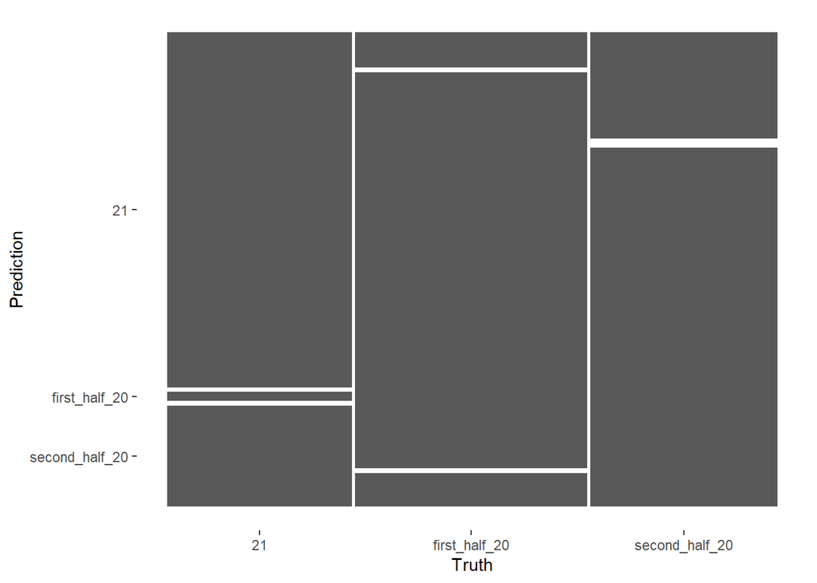

```r
df5_2 = data.frame(prediction2 = prediction2, obs = df_test$target)
df5_2 %>%
  conf_mat(prediction2, obs) %>%
  autoplot
```

**6.** Create another categorical variable from the data and do the following

```r
df <- read.csv('netflix_titles.csv')
df$era <- case_when(df$release_year < 1973 ~"era_1", df$release_year < 1990 ~ "era_2", df$release_year < 2002 ~ "era_3", df$release_year < 2016 ~ "era_4", TRUE ~ "era_5")
```

```
- Plot side-by-side word frequency by different categories of the newly created variable
```

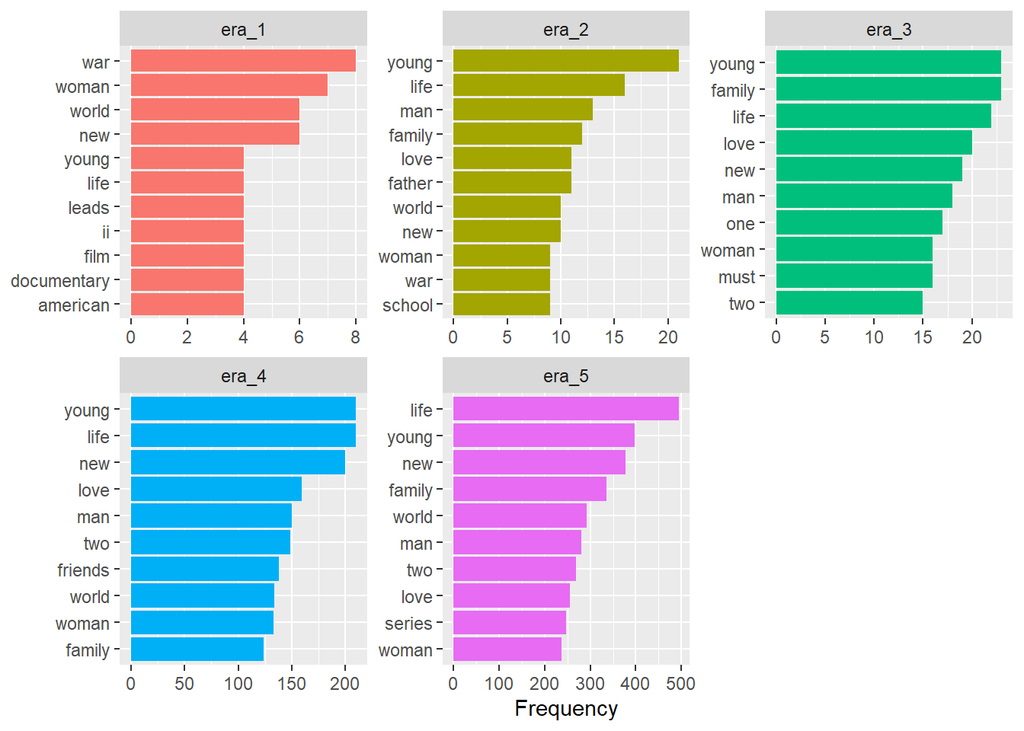

```
- Plot word clouds on different categories of the newly created variable
```

```r
df %>%
  unnest_tokens(input = description, output = word) %>%
  anti_join(get_stopwords()) %>%
  count(era, word, sort = TRUE) %>%
  group_by(era) %>%
  slice_max(n, n = 10) %>%
  ungroup() %>%
  mutate(word = reorder_within(word, by = n, within = era)) %>%
  ggplot(aes(n, word, fill = era)) +
  geom_col(show.legend = FALSE) +
  facet_wrap(~era, scales = "free") +
  labs(x = "Frequency", y = NULL)+
  scale_y_reordered()
```

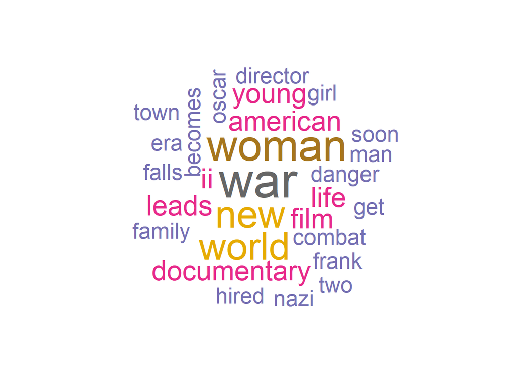

```r
pal <- brewer.pal(8,"Dark2")

df %>%
  filter(era=='era_1') %>%
  unnest_tokens(input = description, output = word) %>%
  anti_join(get_stopwords()) %>%
  count(word, sort = TRUE) %>%
  with(wordcloud(word, n, random.order = FALSE, max.words = 50, colors=pal))
```

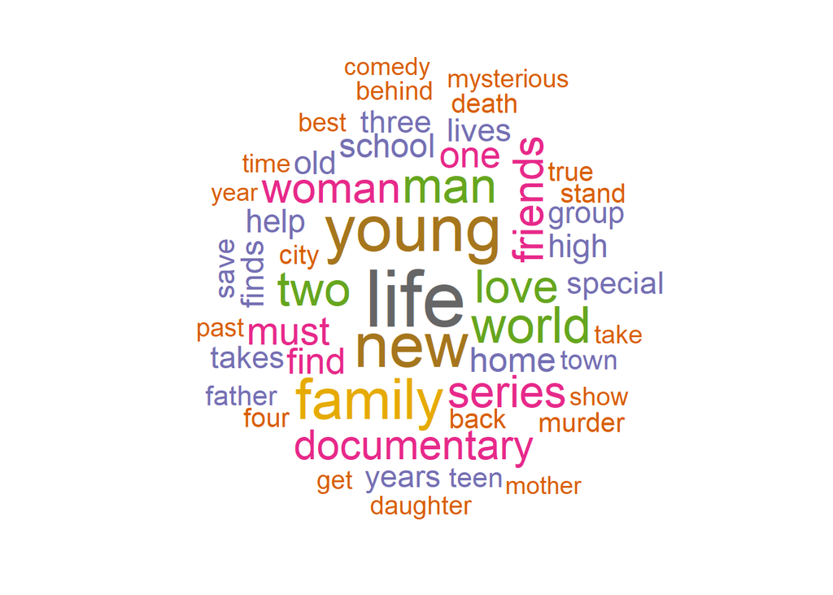

```
- Do sentiment analysis to compare different categories of the newly created variable
```

```r
pal <- brewer.pal(8,"Dark2")

df %>%
  filter(era=='era_5') %>%
  unnest_tokens(input = description, output = word) %>%
  anti_join(get_stopwords()) %>%
  count(word, sort = TRUE) %>%
  with(wordcloud(word, n, random.order = FALSE, max.words = 50, colors=pal))
```

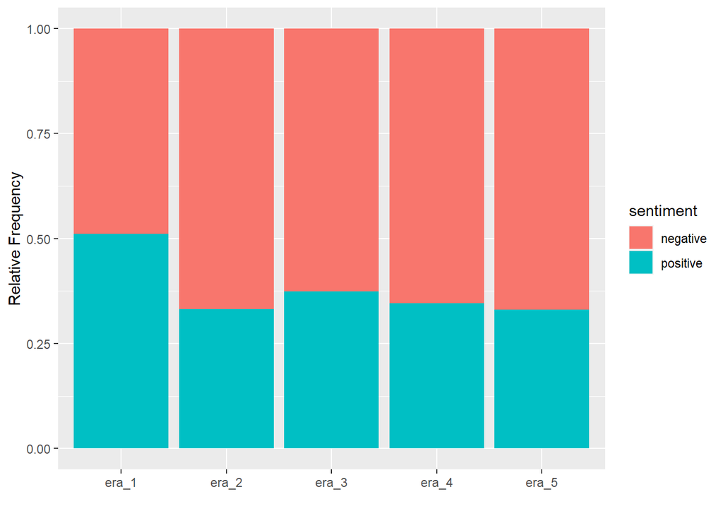

[output not shown]

```r
df %>%
    unnest_tokens(input = description, output = word) %>%
    anti_join(get_stopwords()) %>%
    count(era, word, sort = TRUE) %>%
    group_by(era) %>%
    inner_join(get_sentiments("bing")) %>%
    filter(!is.na(sentiment)) %>%
    count(sentiment, sort = TRUE) %>%
    group_by(era) %>%
    mutate(n = n/sum(n)) %>%
    ggplot(aes(era, n, fill=sentiment))+
    geom_col(position = 'fill')+
    labs(x='', y='Relative Frequency')
```

```r
df <- df %>%
  mutate(target = era) %>%
  select(target, description)

another <- recipe(target~description, data = df) %>%
  step_tokenize(description) %>%
  step_tokenfilter(description, max_tokens = 50) %>%
  step_tfidf(description) %>%
  step_normalize(all_numeric_predictors()) %>%
  step_smote(target) %>%
  prep()
df <- juice(another)

set.seed(2021)
splitIndex <- createDataPartition(df$target, p = .02, list = FALSE)
df_train <- df[splitIndex,]
df_test <- df[-splitIndex,]

ranger3 <- train(target~., data=df_train, method = "ranger")
prediction3 <- predict(ranger3, df_test)
confmatrix3 <- confusionMatrix(data = prediction3, reference = df_test$target)
confmatrix3$overall[1]
```

```
##  Accuracy
## 0.5617127
```

### Animal Reviews Data (Optional)

We will study the Animal Crossing Data at [Kaggle](https://www.kaggle.com/jessemostipak/animal-crossing). The data file is `user_review`

**7.** Download the animal reviews data at this link. Read the data using `read_tsv()` function.

```r
df2 <- read_tsv('user_reviews.tsv')
```

**8.** Create a `rating` variable taking value `good` if the grade is greater than 7 and `bad` otherwise.

```r
df2$rating <- case_when(df2$grade > '7' ~ 'good',TRUE ~ 'bad' )
```

**9.** Do the follows. Notice that the text information is in the `text` variable.

```
- Plot side-by-side word frequency by different categories of the `rating` variable
```

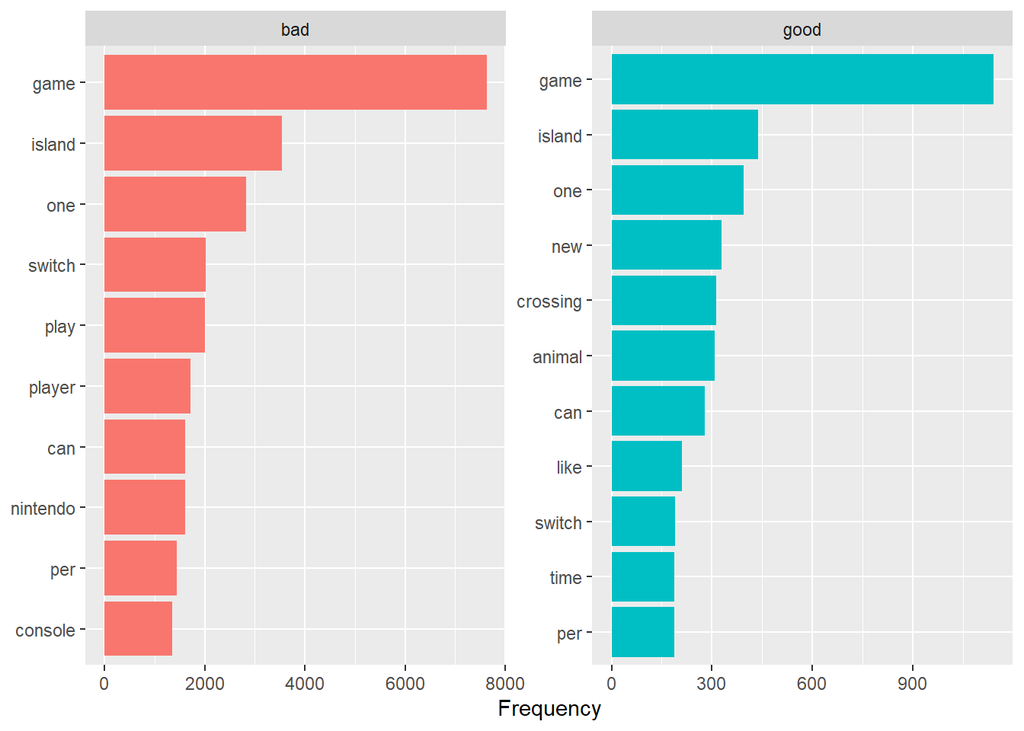

```
- Plot word clouds on different categories of the `rating` variable
```

```r
df2 %>%
  unnest_tokens(input = text, output = word) %>%
  anti_join(get_stopwords()) %>%
  count(rating, word, sort = TRUE) %>%
  group_by(rating) %>%
  slice_max(n, n = 10) %>%
  ungroup() %>%
  mutate(word = reorder_within(word, by = n, within = rating)) %>%
  ggplot(aes(n, word, fill = rating)) +
  geom_col(show.legend = FALSE) +
  facet_wrap(~rating, scales = "free") +
  labs(x = "Frequency", y = NULL)+
  scale_y_reordered()
```

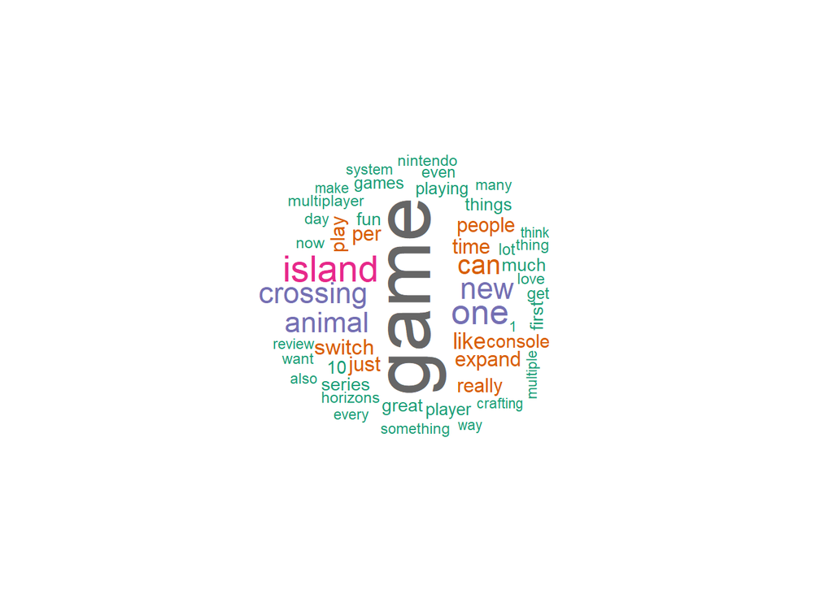

```r
pal <- brewer.pal(8,"Dark2")

df2 %>%
  filter(rating=='good') %>%
  unnest_tokens(input = text, output = word) %>%
  anti_join(get_stopwords()) %>%
  count(word, sort = TRUE) %>%
  with(wordcloud(word, n, random.order = FALSE, max.words = 50, colors=pal))
```

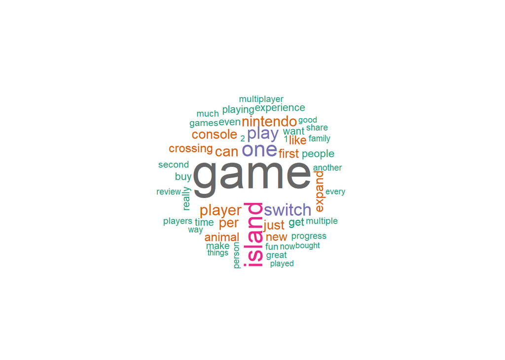

```
- Do sentiment analysis to compare different categories of the `rating` variable
```

```r
pal <- brewer.pal(8,"Dark2")

df2 %>%
  filter(rating=='bad') %>%
  unnest_tokens(input = text, output = word) %>%
  anti_join(get_stopwords()) %>%
  count(word, sort = TRUE) %>%
  with(wordcloud(word, n, random.order = FALSE, max.words = 50, colors=pal))
```

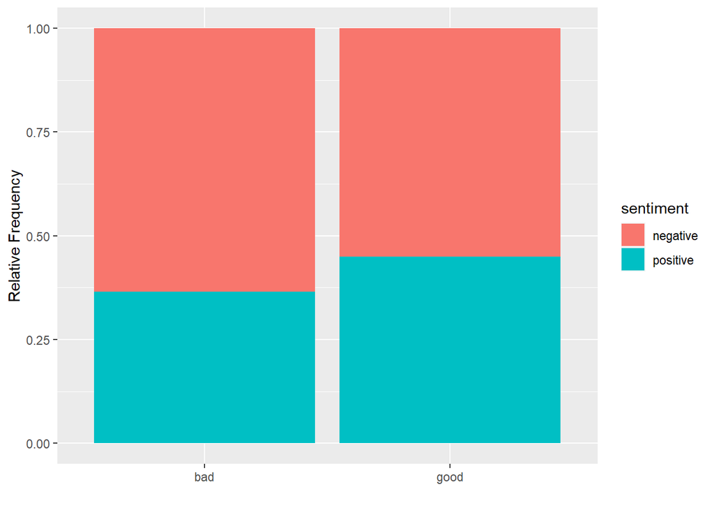

[output not shown]

```r
df2 %>%
    unnest_tokens(input = text, output = word) %>%
    anti_join(get_stopwords()) %>%
    count(rating, word, sort = TRUE) %>%
    group_by(rating) %>%
    inner_join(get_sentiments("bing")) %>%
    filter(!is.na(sentiment)) %>%
    count(sentiment, sort = TRUE) %>%
    group_by(rating) %>%
    mutate(n = n/sum(n)) %>%
    ggplot(aes(rating, n, fill=sentiment))+
    geom_col(position = 'fill')+
    labs(x='', y='Relative Frequency')
```

```r
df2 <- df2 %>%
  mutate(target = rating) %>%
  select(target, text)

last_one <- recipe(target~text, data = df2) %>%
  step_tokenize(text) %>%
  step_tokenfilter(text, max_tokens = 50) %>%
  step_tfidf(text) %>%
  step_normalize(all_numeric_predictors()) %>%
  step_smote(target) %>%
  prep()
df2 <- juice(last_one)

set.seed(2021)
splitIndex <- createDataPartition(df2$target, p = .02, list = FALSE)
df2_train <- df2[splitIndex,]
df2_test <- df2[-splitIndex,]

ranger4 <- train(target ~., data=df2_train, method = "ranger")
prediction4 <- predict(ranger4, df2_test)
confmatrix4 <- confusionMatrix(data = prediction4, reference = df2_test$target)
confmatrix4$overall[1]
```

```
##  Accuracy
## 0.7858516
```